# Project: Investigate No-show appointments Dataset

- Introduction
- Data Wrangling
- Exploratory Data Analysis
- Conclusions

## Introduction

This dataset collects information from 100k medical appointments in Brazil and is focused on the question of whether or not patients show up for their appointment. A number of characteristics about the patient are included in each row. There are alot of answers which can be asked to explore the relationship between each characteristic and No-show result, some of them are:

- Is the age of the patient has an effect in absence at the appointment?
- Does the increasing in number of days between the scheduling and appointment increases the probability of no show?
- Do the patients with scholarship miss the appointment more than who doesn't have it?
- Is receiving an SMS before the appointment really encourage the patient to show up to their appointment?
- Does the number of medical situations make the patient more commitment to his/her appointment?

```python
import numpy as np
import pandas as pd
import matplotlib.pyplot as plt
import seaborn as sns
%matplotlib inline
```

## Data Wrangling

> **Tip**: In this section of the report, you will load in the data, check for cleanliness, and then trim and clean your dataset for analysis. Make sure that you document your steps carefully and justify your cleaning decisions.

### General Properties

```python
df = pd.read_csv('noshowappointments.csv')
df.head()
```

|  | PatientId | AppointmentID | Gender | ScheduledDay | AppointmentDay | Age | Neighbourhood | Scholarship | Hipertension | Diabetes | Alcoholism | Handcap | SMS_received | No-show |
| --- | --- | --- | --- | --- | --- | --- | --- | --- | --- | --- | --- | --- | --- | --- |
| 0 | 2.987250e+13 | 5642903 | F | 2016-04-29T18:38:08Z | 2016-04-29T00:00:00Z | 62 | JARDIM DA PENHA | 0 | 1 | 0 | 0 | 0 | 0 | No |
| 1 | 5.589978e+14 | 5642503 | M | 2016-04-29T16:08:27Z | 2016-04-29T00:00:00Z | 56 | JARDIM DA PENHA | 0 | 0 | 0 | 0 | 0 | 0 | No |
| 2 | 4.262962e+12 | 5642549 | F | 2016-04-29T16:19:04Z | 2016-04-29T00:00:00Z | 62 | MATA DA PRAIA | 0 | 0 | 0 | 0 | 0 | 0 | No |
| 3 | 8.679512e+11 | 5642828 | F | 2016-04-29T17:29:31Z | 2016-04-29T00:00:00Z | 8 | PONTAL DE CAMBURI | 0 | 0 | 0 | 0 | 0 | 0 | No |
| 4 | 8.841186e+12 | 5642494 | F | 2016-04-29T16:07:23Z | 2016-04-29T00:00:00Z | 56 | JARDIM DA PENHA | 0 | 1 | 1 | 0 | 0 | 0 | No |

```python
df.info()
```

```
<class 'pandas.core.frame.DataFrame'>
RangeIndex: 110527 entries, 0 to 110526
Data columns (total 14 columns):
 #   Column          Non-Null Count   Dtype
---  ------          --------------   -----
 0   PatientId       110527 non-null  float64
 1   AppointmentID   110527 non-null  int64
 2   Gender          110527 non-null  object
 3   ScheduledDay    110527 non-null  object
 4   AppointmentDay  110527 non-null  object
 5   Age             110527 non-null  int64
 6   Neighbourhood   110527 non-null  object
 7   Scholarship     110527 non-null  int64
 8   Hipertension    110527 non-null  int64
 9   Diabetes        110527 non-null  int64
 10  Alcoholism      110527 non-null  int64
 11  Handcap         110527 non-null  int64
 12  SMS_received    110527 non-null  int64
 13  No-show         110527 non-null  object
dtypes: float64(1), int64(8), object(5)
memory usage: 11.8+ MB
```

### Data Cleaning

Check if there is duplicated rows

```python
df.duplicated().sum()
```

```
0
```

Drop patient id and appointment id columns because they have no useful information for this investigation

```python
df.drop(['PatientId','AppointmentID'],axis = 1,inplace = True)
```

Convert scheduled day and appointment day column type from string to date time object and then get the date only

```python
df['ScheduledDay'] =  pd.to_datetime(df['ScheduledDay'],format="%Y-%m-%dT%H:%M:%SZ")
```

```python
df['ScheduledDay'] = df['ScheduledDay'].dt.date
```

```python
df['AppointmentDay'] =  pd.to_datetime(df['AppointmentDay'],format="%Y-%m-%dT%H:%M:%SZ")
```

```python
df['AppointmentDay'] = df['AppointmentDay'].dt.date
```

```python
df.info()
```

```
<class 'pandas.core.frame.DataFrame'>
RangeIndex: 110527 entries, 0 to 110526
Data columns (total 12 columns):
 #   Column          Non-Null Count   Dtype
---  ------          --------------   -----
 0   Gender          110527 non-null  object
 1   ScheduledDay    110527 non-null  object
 2   AppointmentDay  110527 non-null  object
 3   Age             110527 non-null  int64
 4   Neighbourhood   110527 non-null  object
 5   Scholarship     110527 non-null  int64
 6   Hipertension    110527 non-null  int64
 7   Diabetes        110527 non-null  int64
 8   Alcoholism      110527 non-null  int64
 9   Handcap         110527 non-null  int64
 10  SMS_received    110527 non-null  int64
 11  No-show         110527 non-null  object
dtypes: int64(7), object(5)
memory usage: 10.1+ MB
```

Replace scheduled day and appointment day columns by the difference in days between them

```python
df['days_between_scheduling_and_appointment'] = (df['AppointmentDay'] - df['ScheduledDay']).dt.days
```

```python
df.drop(['ScheduledDay','AppointmentDay'],axis = 1,inplace = True)
```

Add a new column which conatins the total number of medical situations the pateint has

```python
df['number_of_medical_situations'] = df['Hipertension'] + df['Diabetes'] + df['Alcoholism']
```

```python
df.head()
```

|  | Gender | Age | Neighbourhood | Scholarship | Hipertension | Diabetes | Alcoholism | Handcap | SMS_received | No-show | days_between_scheduling_and_appointment | number_of_medical_situations |
| --- | --- | --- | --- | --- | --- | --- | --- | --- | --- | --- | --- | --- |
| 0 | F | 62 | JARDIM DA PENHA | 0 | 1 | 0 | 0 | 0 | 0 | No | 0 | 1 |
| 1 | M | 56 | JARDIM DA PENHA | 0 | 0 | 0 | 0 | 0 | 0 | No | 0 | 0 |
| 2 | F | 62 | MATA DA PRAIA | 0 | 0 | 0 | 0 | 0 | 0 | No | 0 | 0 |
| 3 | F | 8 | PONTAL DE CAMBURI | 0 | 0 | 0 | 0 | 0 | 0 | No | 0 | 0 |
| 4 | F | 56 | JARDIM DA PENHA | 0 | 1 | 1 | 0 | 0 | 0 | No | 0 | 2 |

## Exploratory Data Analysis

### Is the age of the patient has an effect in absence at the appointment?

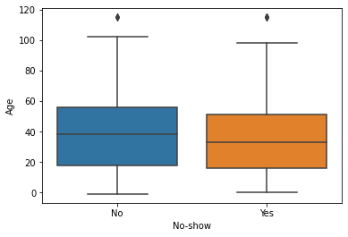

```python
sns.boxplot('No-show','Age',data = df);
```

### Does the increasing in number of days between the scheduling and appointment increases the probability of no show?

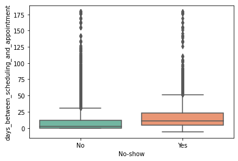

```python
sns.boxplot('No-show','days_between_scheduling_and_appointment',data = df,palette = "Set2")
```

### Do the patients with scholarship miss the appointment more than who doesn't have it?

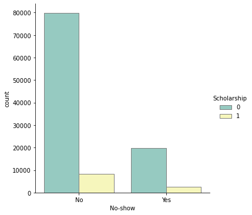

```python
sns.catplot(hue="Scholarship", x="No-show", kind="count",palette="Set3", edgecolor="0.5",data=df)
```

```python
print("Percentage of patients who hasn't a scholarship and didn't show up = ",df[(df['Scholarship']== 0) & (df['No-show']== 'Yes')].value_counts().sum()/df[df['No-show']== 'Yes'].value_counts().sum())
print("Percentage of patients who has a scholarship and didn't show up = ",df[(df['Scholarship']== 1) & (df['No-show']== 'Yes')].value_counts().sum()/df[df['No-show']== 'Yes'].value_counts().sum())
print("Percentage of patients who hasn't a scholarship and showed up = ",df[(df['Scholarship']== 0) & (df['No-show']== 'No')].value_counts().sum()/df[df['No-show']== 'No'].value_counts().sum())
print("Percentage of patients who has a scholarship and showed up = ",df[(df['Scholarship']== 1) & (df['No-show']== 'No')].value_counts().sum()/df[df['No-show']== 'No'].value_counts().sum())
```

```
Percentage of patients who hasn't a scholarship and didn't show up =  0.8844930328419732
Percentage of patients who has a scholarship and didn't show up =  0.11550696715802679
Percentage of patients who hasn't a scholarship and showed up =  0.9060969526573553
Percentage of patients who has a scholarship and showed up =  0.09390304734264465
```

### Is receiving an SMS before the appointment really encourage the patient to show up to their appointment?

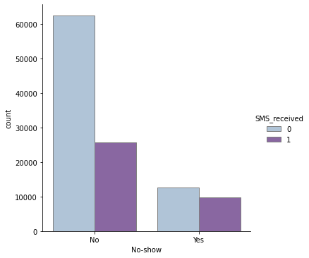

```python
sns.catplot(x="No-show", hue="SMS_received", kind="count",
            palette="BuPu", edgecolor="0.5",
            data=df)
```

```python
print("Percentage of patients who didn't receive an SMS and didn't show up = ",df[(df['SMS_received']== 0) & (df['No-show']== 'Yes')].value_counts().sum()/df[df['No-show']== 'Yes'].value_counts().sum())
print("Percentage of patients who received an SMS and didn't show up = ",df[(df['SMS_received']== 1) & (df['No-show']== 'Yes')].value_counts().sum()/df[df['No-show']== 'Yes'].value_counts().sum())
print("Percentage of patients who didn't receive an SMS and showed up = ",df[(df['SMS_received']== 0) & (df['No-show']== 'No')].value_counts().sum()/df[df['No-show']== 'No'].value_counts().sum())
print("Percentage of patients who received an SMS and showed up = ",df[(df['SMS_received']== 1) & (df['No-show']== 'No')].value_counts().sum()/df[df['No-show']== 'No'].value_counts().sum())
```

```
Percentage of patients who didn't receive an SMS and didn't show up =  0.5616291052466509
Percentage of patients who received an SMS and didn't show up =  0.43837089475334917
Percentage of patients who didn't receive an SMS and showed up =  0.7086658806457464
Percentage of patients who received an SMS and showed up =  0.2913341193542536
```

### Does the number of medical situations make the patient more commitment to his/her appointment?

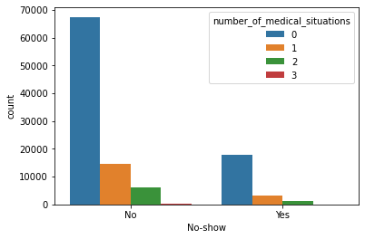

```python
sns.countplot(hue='number_of_medical_situations', x='No-show', data=df)
```